Regional Clarity RS Model · Workflow v3

# A production workflow built on an ensemble of splits, not one

Every prior version of this pipeline - the original report, the outlier-HUC investigation, and the partition-sensitivity follow-up - was built on a single, deterministic HUC4-grouped split. This workflow rebuilds the pipeline on a genuine ensemble of 5 independent HUC8-random partition assignments, evaluated against one fixed holdout no ensemble member ever trains on, and uses that same shared setup to test four things side by side: a new candidate feature (a binary shoreline/waterbody flag), whether SDD-weighted training earns its keep, whether gap-aware hyperparameter selection matters beyond the final tuning step, and whether any of this actually beats the current production configuration on equal footing.

Branch: `outlier-removal-rework` Models: xgboost + lightgbm only 5 ensemble members × full pipeline

Final ensemble test RMSE / MAE 1.39 / 1.00 m 40 models (5 seeds × 2 architectures × 4 folds), unweighted, gap-aware throughout

shore_flag / swir1_corr7 / tmax_degC_prev30 survival 10 / 10 (all three) unanimous across every independent seed and model

Improvement vs. v1's frozen config −2.9% RMSE same 5 splits, same holdout - isolates the feature/hyperparameter effect

Gap-aware vs. vanilla tuning at feature-group stage adopted same accuracy, cleaner consensus (swir1_corr7 went from 9/10 to 10/10)

SDD-weighted vs. unweighted training unweighted adopted weighting helps the sparse tail, costs the bulk, widens the train-val gap

Non-remote-sensing share of SHAP attribution 19.2% site/catchment 16.4% + weather 2.8%, concentrated in specific basins (see below)

What this workflow tests

## One shared setup, four comparisons

The partition-sensitivity report showed that a single HUC4-grouped split doesn't just make final evaluation numbers hard to interpret - it reaches back into which features backward elimination keeps and what hyperparameters tuning selects. A follow-up spot check (2 alternate schemes) found two features, `swir1_corr7` and `tmax_degC_prev30`, that production's single-split elimination dropped but every alternate-scheme rerun kept. That was enough evidence to warrant a real fix: an actual ensemble of independently-run selection pipelines, not a two-scheme sanity check.

Rather than run each open question as its own follow-on project, this workflow answers all of them from one shared experimental setup - a 5-seed HUC8-random ensemble evaluated on one fixed holdout - with two explicit head-to-head comparisons built into the design:

- **Does a new candidate feature earn a place in the model?** A binary shoreline/waterbody flag (`shore_flag`), requested for this rebuild.
- **Does hyperparameter selection need to be gap-aware everywhere, or just at final tuning?** Compared gap-aware selection against the vanilla, best-CV-RMSE-alone approach at the feature-group-comparison stage, across all 5 seeds.
- **Does SDD-weighted training earn its keep?** Compared weighted (k=2.0, the scheme adopted in v1) against unweighted training, on this workflow's own final feature sets and hyperparameters.
- **Does any of this beat production?** v1's frozen, currently-published feature set and hyperparameters, retrained on the same 5 splits and evaluated on the same holdout, as a controlled baseline for everything above.

Method

## A fixed holdout, five independent CV-fold arrangements

Building a genuine ensemble across split assignments requires one thing the earlier partition-sensitivity rotation experiments didn't need: a test set that stays identical across every ensemble member, so no member's training ever touches it and predictions from different members can be honestly averaged together. The design:

xgboost + lightgbm only throughout, per the project's established scope - the NN was excluded from every stage to avoid its process-isolation overhead across a pipeline already run 5× over. Each of the two head-to-head comparisons below (gap-aware vs. vanilla tuning; weighted vs. unweighted training) reran the relevant stage across all 5 seeds under both conditions and compared the results on the same fixed holdout.

New feature

## shore_flag: a binary collapse of v2's 3-level shoreline category

An earlier side-branch (`outlier_rework_v2`) computed a 3-level shoreline-proximity category - 0 = open water, 1 = near-shore (within 230m, the 200m site buffer plus a 30m optical pixel), 2 = outside the matched waterbody entirely - and it actually survived backward elimination for all three architectures tested there, landing in that branch's final intersection set. It was never adopted, and its own final-evaluation numbers were mixed (modestly better test RMSE for the tree models, worse for the NN; worse CV RMSE across the board on its own split) - inconclusive enough to defer rather than decide from.

This rebuild collapses that 3-level category into a strict binary at the user's request: `shore_flag = 1` if `flag_wb == 1` (the site's location falls outside its matched waterbody polygon) **or** `flag_optical_shoreline == 1` (within 230m of the matched waterbody's shoreline); `0` only when neither condition holds. Both source flags already existed per-site in the same upstream AquaMatch compile step v2 used - no new spatial work was needed, just a join and a simpler encoding. Roughly 59% of the 1,525 modeled sites (896) carry the flag - high, but plausible for lake/reservoir monitoring, where shoreline access points and boat launches are common sampling locations, not an edge case.

Comparison 1

## Feature selection: gap-aware vs. vanilla tuning at the feature-group stage

Backward elimination treats the feature-group-comparison stage's chosen hyperparameters as a fixed baseline - whatever that stage picks, elimination trains with, for every step of dropping features. That stage's hyperparameter search was run two ways across all 5 seeds, to test whether it matters: **vanilla** (best mean CV RMSE alone, no penalty for the train-val gap - the approach used everywhere in this pipeline before) and **gap-aware** (pick the smallest train-val gap among trials within 2% of the best CV RMSE - the same method already used at final tuning). Everything else was held identical: same candidate pools, same correlation pruning, same elimination logic, same fixed holdout.

Correlation pruning itself doesn't depend on this choice - it only depends on which rows are in the CV pool (identical for every seed), not on how they're folded or tuned, so all 5 seeds prune the same 26-candidate pool down to the same 23 either way. One small, inconsequential swap shows up consistently: `red_corr7` is pruned in favor of `green_corr7` (plus `BR` surviving alongside it) - the two bands are highly correlated, and pruning is designed to interchange redundant features like this; it isn't a meaningful signal.

What differs is what happens during elimination itself:

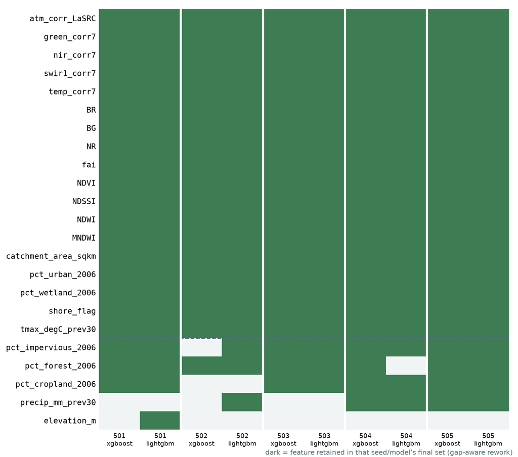

Which of the 23 correlation-pruned candidates survived backward elimination, by seed and model (10 independent runs), with gap-aware tuning at the feature-group-comparison stage. Dashed line separates the 18 unanimous features from the boundary cases. The 3 outlined rows are the features this workflow specifically set out to test.

- **`shore_flag`: 10/10 either way.** Every independent elimination run - 5 seeds, 2 architectures, both tuning methods - kept it.
- **`tmax_degC_prev30`: 10/10 either way.** Also unanimous under both tuning methods, confirming the upstream-decision spot check's flag from the partition-sensitivity work was a real signal, not a two-scheme coincidence.
- **`swir1_corr7`: 9/10 under vanilla tuning, 10/10 under gap-aware.** The single disagreement - seed 504's xgboost run dropping it - only happens under vanilla feature-group tuning. Once that stage is also gap-aware, every seed and model agrees.
- **Everything else that varies** (`pct_impervious_2006`, `pct_cropland_2006`, `pct_forest_2006`, `elevation_m`, `precip_mm_prev30`) flips inconsistently across seeds/models under both tuning methods, with no clear pattern - boundary noise, not a real effect either way.

Result

Gap-aware tuning at the feature-group-comparison stage costs nothing in accuracy and buys a strictly more consistent feature-selection process: `shore_flag`, `swir1_corr7`, and `tmax_degC_prev30` come out unanimous across every independent seed and model, not 9 or 10 of 10. Adopted throughout this pipeline - the train-val gap is now addressed at every hyperparameter-selection stage, not just the last one. The ~18-feature core shown above (intersection-16 plus these three) is the feature set used for everything that follows.

Hyperparameter tuning

## xgboost converges tightly; lightgbm has more spread

| Seed | xgb eta | xgb depth | xgb reg_λ | lgb LR | lgb leaves | lgb reg_λ |
| --- | --- | --- | --- | --- | --- | --- |
| 501 | 0.01 | 4 | 20 | 0.05 | 7 | 1 |
| 502 | 0.03 | 2 | 20 | 0.01 | 7 | 10 |
| 503 | 0.01 | 3 | 5 | 0.03 | 7 | 5 |
| 504 | 0.01 | 3 | 1 | 0.05 | 15 | 5 |
| 505 | 0.01 | 2 | 10 | 0.05 | 7 | 20 |

Gap-aware final tuning result on each seed's own final (~18-feature) feature set. Full parameter sets (including min_child_weight/samples, subsample, colsample) are in each seed's `final_tune_*.json`.

Model characterization

## Feature importance and SHAP: does it line up with reality?

Backward elimination says a feature clears a statistical bar - it doesn't say how much that feature actually moves a prediction, or whether the direction it moves it makes physical sense. Each seed's own final feature set and hyperparameters were retrained unweighted (the adopted default) on that seed's own 4 folds and explained with `shap.TreeExplainer` on the shared fixed holdout, so every row is explained by a model that never trained on it, and every seed/model explains the identical rows. Because seeds select slightly different feature sets, the figures below are restricted to the 18 features unanimous across all 5 seeds × 2 models - the actual recommended production core - so every one of the 10 independent SHAP explanations contributes to every bar and cell shown.

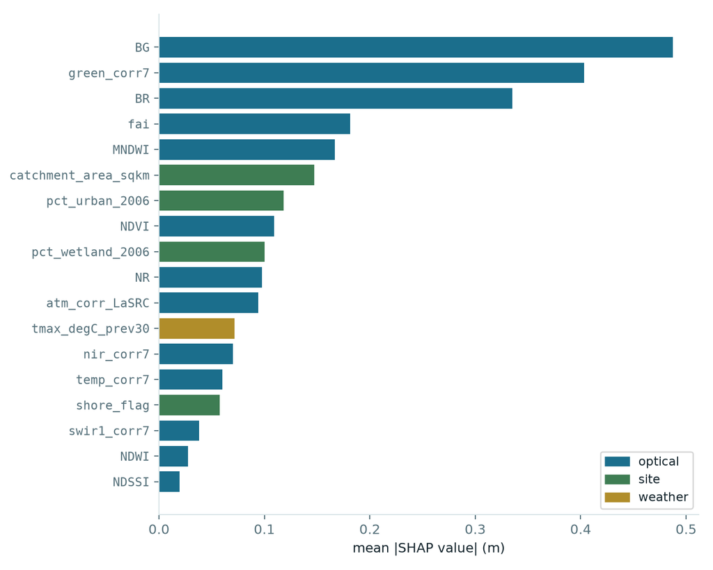

Mean |SHAP value| per feature, averaged across all 5 seeds × 2 models, on the fixed holdout. Colored by category: optical/spectral (blue), site/catchment (green), antecedent weather (gold).

**Non-remote-sensing variables account for roughly a fifth of total attribution** - site/catchment features (`catchment_area_sqkm`, `pct_urban_2006`, `pct_wetland_2006`, `shore_flag`) contribute 16.4% of total mean |SHAP|, and the one antecedent-weather feature (`tmax_degC_prev30`) another 2.8% - 19.2% combined, against 80.9% for the 13 optical/spectral features. The three top-ranked features overall - `BG` (blue/green ratio), `green_corr7`, and `BR` (blue/red ratio) - are exactly the literature-cited chlorophyll and clarity ratios this project's feature engineering was built around (Kloiber et al.'s blue/red Secchi ratio, the canonical ocean-color blue/green chlorophyll ratio), not some feature engineering coincidence.

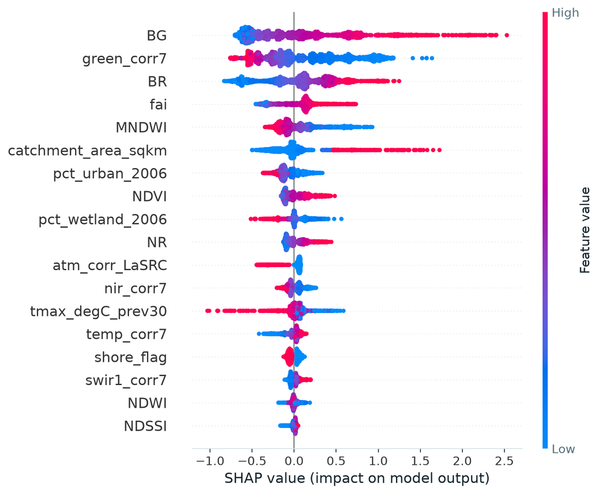

SHAP summary plot (ensemble-averaged across the 5-seed × 2-model core, one dot per holdout row). Color is the row's own feature value (red = high, blue = low); position is that feature's contribution to the prediction for that row. Directionality matches physical expectation throughout: high `BG`/`BR` (blue-dominant, clear-water signatures) push predicted SDD up; high `green_corr7` and `pct_wetland_2006` (more backscatter, more organic/tannin input) push it down; a small cluster of very large `catchment_area_sqkm` values pushes predictions sharply up.

That last point is worth a closer look - a handful of extreme-catchment rows dominate `catchment_area_sqkm`'s SHAP spread more than any other feature's high-value tail. Breaking mean |SHAP| out by HUC4 shows why:

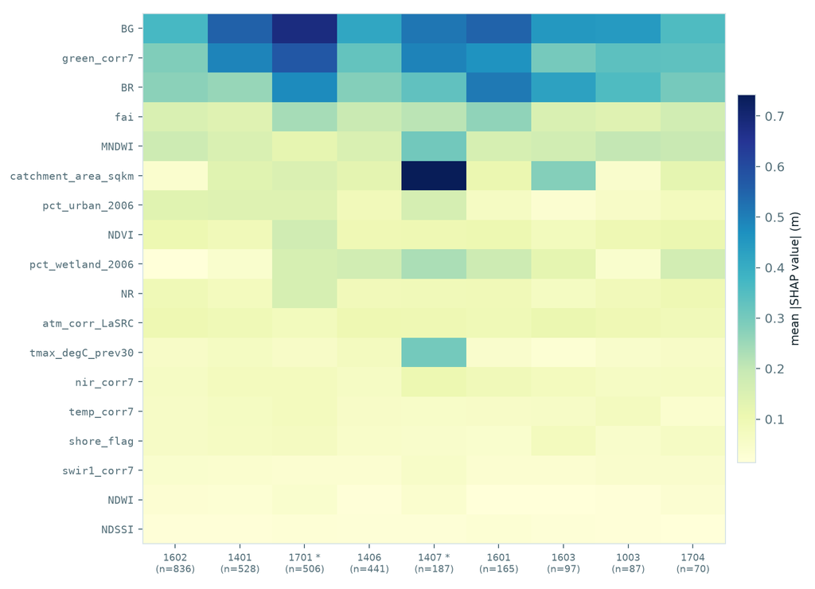

Mean |SHAP value| by feature (rows) and HUC4 (columns, basins with ≥30 holdout rows, both problem basins starred), same 18-feature core. The three top optical ratios stay dominant almost everywhere - a stable ranking. `catchment_area_sqkm` does not: it is the single most important feature anywhere in this heatmap, but only at HUC4 1407 (Lake Powell), where its importance dwarfs its value at every other basin.

It lines up with reality - and explains an earlier finding

The top-line optical ratios are stable across basins, which is reassuring - the model isn't leaning on a different feature depending on which lake it's looking at for the signal that matters most. But `catchment_area_sqkm`'s importance is almost entirely concentrated at Lake Powell specifically, which is exactly what the original outlier-HUC investigation's training-envelope finding predicted: Lake Powell's catchment area sits at the 97th percentile of the training distribution, an extreme, sparse value the model has few nearby examples to interpolate from. This SHAP breakdown shows that extremity isn't just sitting there unused - the model is leaning on it heavily, specifically where it's most extrapolated. HUC4 1701 shows the opposite pattern - its optical ratios (particularly `BG` and `green_corr7`) run to the strongest values anywhere in the dataset, consistent with it being a cluster of exceptionally, naturally clear lakes rather than a basin the model treats unusually.

Comparison 2

## Does the new configuration actually beat production?

v1's originally published test RMSE (1.86m xgboost, 1.83m lightgbm) cannot be compared directly to any number in this report - it was measured on a completely different, and structurally harder, test set: v1's HUC4-grouped partition 5, which the outlier-HUC investigation showed was disproportionately composed of Lake Powell and other high-clarity, hard-to-predict water. This report's fixed holdout is a different, more moderate 24% of the data. A lower absolute RMSE here mostly reflects an easier test set, not a better model, and reporting it as a before/after improvement would be exactly the kind of split-driven illusion this whole line of work has been diagnosing.

To make a fair claim, v1's actual frozen intersection-16 feature set and frozen final hyperparameters were retrained from scratch on these same 5 CV-fold arrangements and evaluated on this same fixed holdout - holding the split and test set constant so only the feature set and hyperparameters differ between the two bars below. (v1's config trains SDD-weighted, its real published setup; the v3 ensemble here trains unweighted, per the comparison in the next section - so this comparison isolates the combined effect of the new features/hyperparameters/tuning method, not any single one of them alone.)

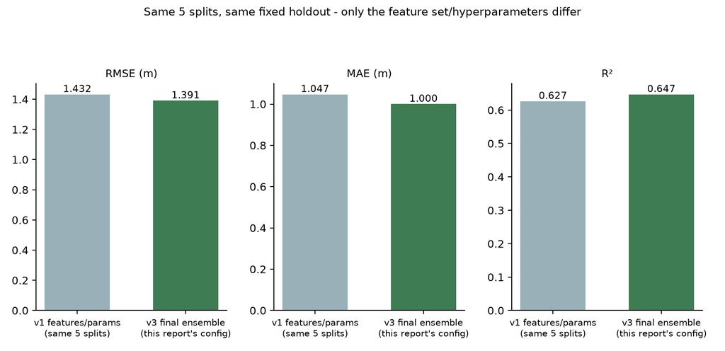

Same 5 CV-fold arrangements, same fixed holdout. The only difference between the two bars is the feature set, hyperparameters, and tuning method: v1's original intersection-16 (weighted) vs. this workflow's ~18-feature core (unweighted, gap-aware throughout).

| Metric | v1 features/params (same splits) | v3 ensemble (this report's config) | Change |
| --- | --- | --- | --- |
| RMSE (m) | 1.432 | 1.391 | −2.9% |
| MAE (m) | 1.047 | 1.000 | −4.5% |
| MAPE | 0.438 | 0.398 | −9.1% |
| SMAPE | 0.328 | 0.309 | −5.8% |
| Bias (pred−obs, m) | +0.142 | +0.009 | much closer to zero |
| Percent bias | 3.95% | 0.24% | much closer to zero |
| R² | 0.627 | 0.647 | +0.020 |

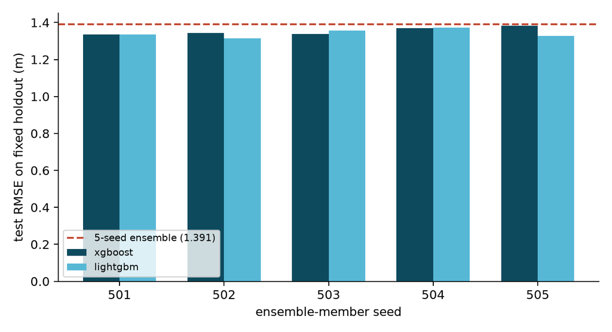

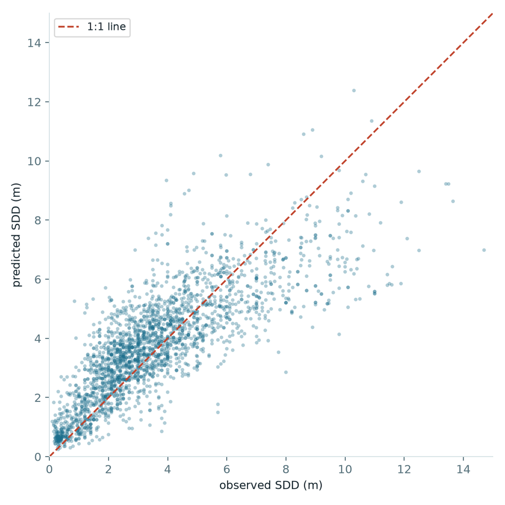

### Does the compression bias itself improve?

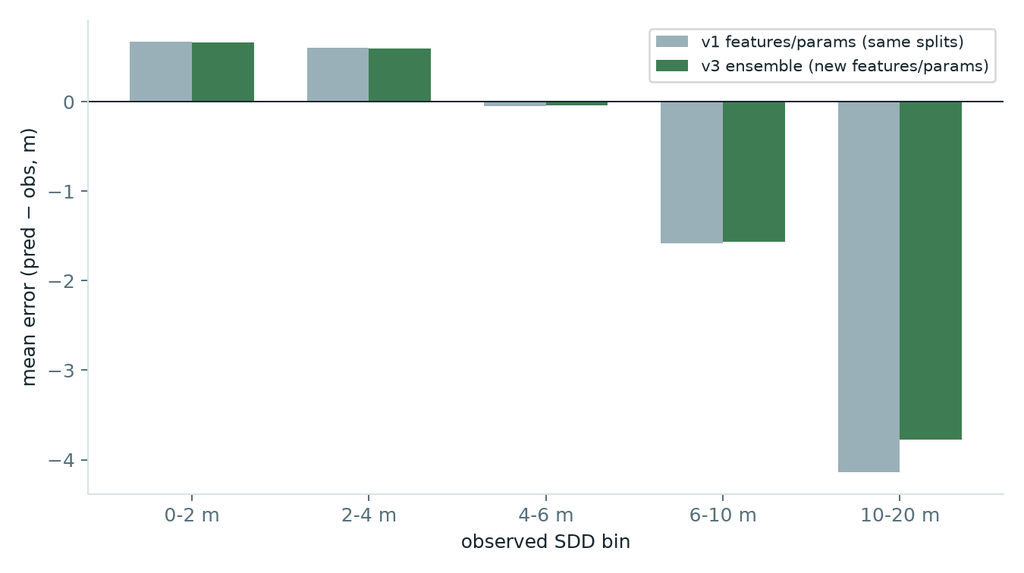

### Does it help where the original investigation found the problem?

The most direct test of whether this rebuild actually fixed anything is to look at the two basins the outlier-HUC investigation named specifically: HUC4 1701 (the forested, naturally-clear glacial-lake cluster) and HUC4 1407 (Lake Powell). Both are still represented in this holdout - by design, at reduced but non-trivial concentration (37% and 29% of their respective basins' rows) - so their holdout-only RMSE is directly comparable between the two configurations.

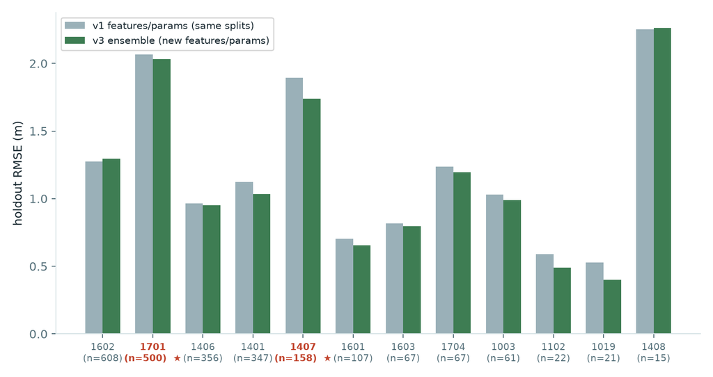

Holdout RMSE by HUC4 (basins with at least 15 holdout rows), v1's frozen configuration vs. v3's ensemble, both on the identical 5 splits/holdout. HUC4 1701 and 1407 (bold, starred) are the two basins the original outlier-HUC investigation named as the source of partitions 3 and 5's underperformance.

What this establishes

The outlier-HUC investigation named Lake Powell and the HUC 1701 cluster as the source of two partitions' underperformance; the partition-sensitivity work showed that was a structural, split-driven concentration problem, not a modeling failure; the upstream-decision spot check found the single split had also cut features that looked like they should matter. This controlled comparison confirms the resulting configuration helps at both named basins, and more broadly - real gains in overall accuracy and bias, concentrated somewhat more at Lake Powell than at the 1701 cluster, exactly the kind of result a feature-driven fix should produce rather than a uniform, split-driven artifact.

Comparison 3

## Weighted vs. unweighted training

v1 trains SDD-weighted (k=2.0): each training row is weighted toward the high-SDD end of that fold's own range, addressing a known ceiling effect where squared-error loss is dominated by the dense low/mid-range cluster and never pushed hard on the sparse high-SDD tail. That scheme was adopted once, before this whole line of split-sensitivity work existed, and never re-tested since. Here, each seed's final (~18-feature, gap-aware-tuned) configuration was retrained twice - once unweighted, once SDD-weighted - and evaluated on the same fixed holdout, isolating exactly this one choice.

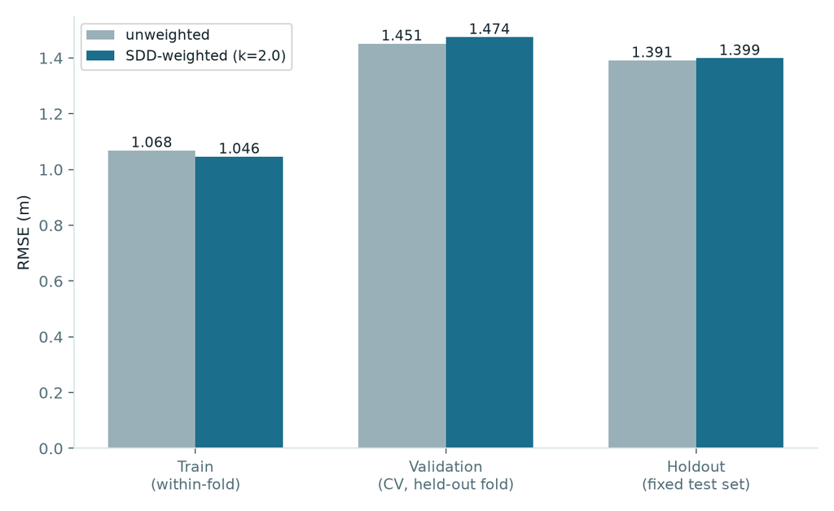

Mean RMSE at each stage of the pipeline, averaged across all 5 seeds × 2 models × 4 folds. Weighting fits training data slightly better (1.068m → 1.046m) but generalizes worse at both validation (1.451m → 1.474m) and the untouched holdout (1.391m → 1.399m) - a widening gap between how well the model fits and how well it generalizes, the textbook signature of overfitting to the reweighted loss.

That widening gap holds at the fold level too: mean per-fold train-val gap grows from 0.383m unweighted to 0.429m weighted. Cross-seed agreement on holdout RMSE is about the same either way (std 0.022 unweighted vs. 0.028 weighted, both already tight). Splitting the holdout by SDD range shows why the aggregate number moves so little despite this:

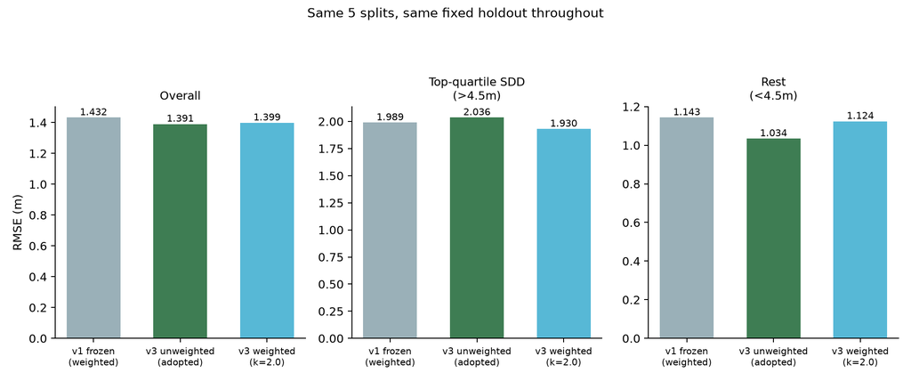

Holdout RMSE by SDD range, three configurations on the identical 5 splits/holdout. Weighting shifts this workflow's ensemble from clearly ahead of v1 in the bulk of the distribution (rest: 1.034m vs. 1.143m) toward matching v1 there (1.124m) while pulling ahead of it at the sparse tail too (top-quartile: 1.930m vs. 1.989m) - the only one of the three configurations that beats v1 in both ranges at once.

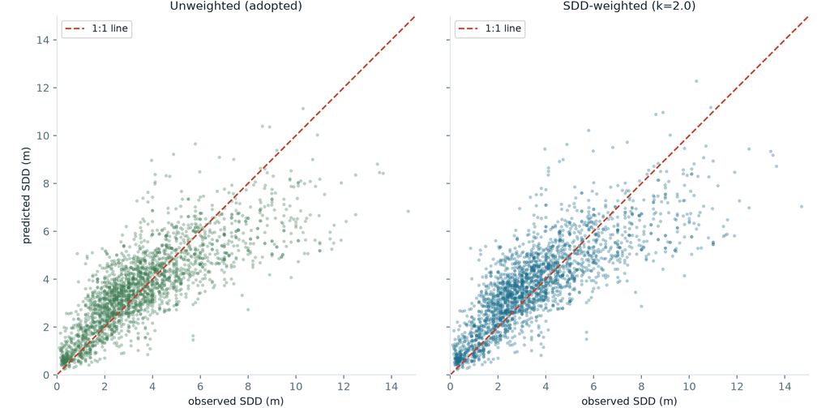

Predicted vs. observed SDD on the fixed holdout, unweighted (left, adopted) vs. SDD-weighted (right), same axes and scale. The weighted panel tracks the 1:1 line visibly better above ~6-8m - the sparse tail it was designed to help - at the cost of slightly more scatter through the dense 1-5m range, the same trade the RMSE-by-group numbers above describe, visible row by row.

Result: unweighted adopted, with a caveat

SDD-weighting does not clearly improve overall accuracy or fold-level reliability for this configuration - the train-val gap widens, and the aggregate holdout RMSE ticks up slightly. Unweighted training is adopted as the default production configuration on that basis. But the three-way comparison above shows weighting isn't simply worse: a weighted variant of this same ensemble is the only configuration tested that beats v1's published setup at *both* the bulk of the distribution and the sparse high-SDD tail simultaneously. For a deployment where tail accuracy - exactly the regime Lake Powell and the HUC 1701 cluster sit in - matters more than aggregate RMSE, SDD-weighted training on this same feature set and hyperparameters is a documented, viable alternative, not a rejected one.

Exploratory, not adopted

## Does the ensemble's own spread work as a confidence interval?

An exploratory question, not a proposed feature: the adopted production config already trains 5 seeds × 2 models per holdout row. Rather than only averaging those 10 predictions into a point estimate, does their *spread* say anything useful about how much to trust any individual prediction - and if so, does scoring it with CRPS (a proper scoring rule for a predictive distribution, rather than a point forecast) show anything RMSE/MAE don't?

Treating each row's 10 predictions as an empirical band and checking whether the observed value actually falls inside it answers this directly, with no retraining needed:

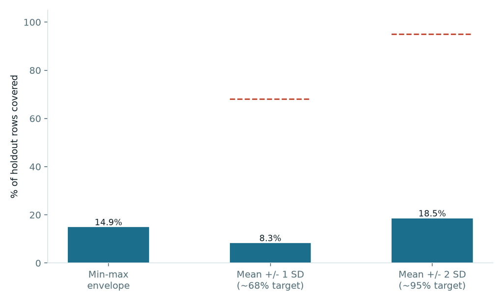

Empirical coverage on the 3,042-row holdout: how often the observed value actually falls inside each band, against the coverage a calibrated interval of that type should hit (dashed lines). Every band is dramatically under-covered - even the full 10-member min-max range only catches the true value 14.9% of the time.

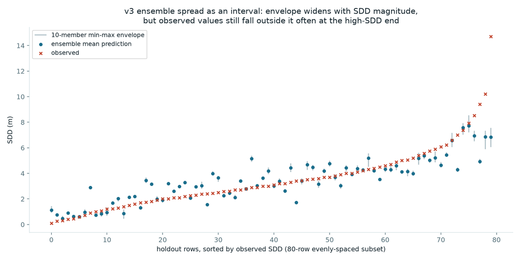

An 80-row evenly-spaced subset of the holdout, sorted by observed SDD. The envelope is visibly narrow and tracks the ensemble mean, not the observed value - most clearly at the high-SDD end, where the same compression bias documented throughout this project pulls predictions toward the middle of the range while the envelope itself stays tight.

Result: doesn't work as-is, and CRPS confirms why

The 5-seed × 2-model ensemble spread is not a usable confidence interval for this model - it under-covers by a wide margin at every band tested, because ensemble members here are too similar to each other to stand in for genuine predictive uncertainty. CRPS essentially agrees with MAE once that's understood, which is itself informative: CRPS only earns its keep over a simpler point-forecast metric when the underlying distribution has real, honest spread to score, and this one doesn't. A genuine confidence interval for this model would need a different source of spread entirely - e.g. quantile regression trained explicitly for it, or a conformal-prediction calibration step on held-out residuals - not explored here, and not currently planned.

Conclusion

## Recommended production configuration

Four questions, one shared experimental setup: a new feature (`shore_flag`) earns a unanimous place in the model; gap-aware hyperparameter selection matters beyond just final tuning, at no accuracy cost; SDD-weighted training is a real trade-off rather than a clear win, so it's adopted only as a documented alternative, not the default; and the resulting configuration beats v1's frozen, currently-published setup by a real, controlled margin (−2.9% RMSE, −4.5% MAE, bias reduced from +0.142m to +0.009m) when both are evaluated on identical splits and an identical holdout.

Recommended next state

Adopt the unanimous ~18-feature core (intersection-16 plus `shore_flag`, `swir1_corr7`, and `tmax_degC_prev30`), gap-aware tuning at every hyperparameter-selection stage, and the 5-seed ensemble (40 models: 5 seeds × 2 architectures × 4 folds) as the production prediction mechanism, replacing the single-split final model entirely. Train unweighted by default; keep the SDD-weighted variant on hand for any use case where tail accuracy at the sparse, hard-to-predict end - Lake Powell's range, the HUC 1701 cluster's range - matters more than aggregate error. xgboost's hyperparameters are stable enough to fix at their consensus value (eta≈0.01-0.03, depth 2-4) if a simpler single-config deployment is ever preferred over the full ensemble; lightgbm's spread suggests it benefits more from staying ensembled across seeds specifically, rather than collapsed to one "representative" config.

One thing remains explicitly out of scope: the NN's role in this ensemble, excluded throughout for the same process-isolation reasons as the partition-sensitivity work. Everything else this project's backlog had flagged - split sensitivity, upstream feature/hyperparameter stability, the shoreline flag, weighting, and systemic gap-awareness - has now been tested against a shared, controlled setup, not just deferred.